# Lecture 05: Building Tables

## Ranges

### Ranges

- A range is an array of consecutive numbers
  - `np.arange(stop)`: An array of increasing integers from `0` up to `stop`
  - `np.arange(start, stop)`: An array of increasing integers from `start` up to `stop`
  - `np.arange(start, stop, step)`: A range with step between consecutive values
- The range always includes `start` but excludes `stop`

### Demo: Ranges

Make an array explicitly using `make_array` and then construct it and several others using `np.arange`. Access items in an array using the `item` method. Explore the documentation for `np.arange` and force some common errors.

For those with experience using Python arrays, keep in mind that this course does not use the bracket notation `[]` to access items in an array and that may trigger an error in the auto-grader on assignments.

```python
make_array(0, 1, 2, 3, 4, 5)
```

```
array([0, 1, 2, 3, 4, 5])
```

```python
np.arange(0, 6, 1)
```

```
array([0, 1, 2, 3, 4, 5])
```

```python
np.arange(3, 45, 5)
```

```
array([ 3,  8, 13, 18, 23, 28, 33, 38, 43])
```

```python
# np.arange(start, stop, step)   Note: never reachers the 'stop'.
```

```python
np.arange(6)  # default starts at 0 and counts by 1s.
```

```
array([0, 1, 2, 3, 4, 5])
```

```python
np.arange(0, 2, 0.25)
```

```
array([ 0.  ,  0.25,  0.5 ,  0.75,  1.  ,  1.25,  1.5 ,  1.75])
```

```python
a = np.arange(8)
a
```

```
array([0, 1, 2, 3, 4, 5, 6, 7])
```

```python
5 * a
```

```
array([ 0,  5, 10, 15, 20, 25, 30, 35])
```

```python
a - 6
```

```
array([-6, -5, -4, -3, -2, -1,  0,  1])
```

```python
# An IndexError  index STARTS at 0
# a.item(8)
```

```python
# to append an item to an array
np.append(a, 20)
```

```
array([ 0,  1,  2,  3,  4,  5,  6,  7, 20])
```

## Ways to Create a Table

- `Table.read_table(filename)` - reads a table from a csv file
- `Table()` - an empty table
- and… `select`, `drop`, `where`, `sort` and a few other table methods all create new tables
- The table methods `with_column` and `with_columns` adds column(s) to the end of the table and creates a new table.

### Demo: Creating a Table from Scratch

Create a table containing information on the major east-west streets north of the Ocean campus and how far they are from campus. Make sure how to see that most table methods will end up creating a new table and not modify the original one.

[Google Maps near CCSF - Ocean Campus](https://goo.gl/maps/QVR57VvqKWqLeSA9A)

```python
from IPython.display import IFrame
IFrame('https://www.google.com/maps/embed?pb=!1m10!1m8!1m3!1d6311.10985715617\
7!2d-122.4451173!3d37.7301236!3m2!1i1024!2i768!4f13.1!5e0!3m2!1sen!2sus!4v1675\
197446609!5m2!1sen!2sus', 600, 450)
```

[interactive chart not shown]

```python
# look at the four streets parallel to Judson
streets = make_array('Judson', 'Staples', 'Flood', 'Hearst')
streets
```

```
array(['Judson', 'Staples', 'Flood', 'Hearst'],
      dtype='<U7')
```

```python
# creates a blank table
Table()
```

```python
# adds column
northside = Table().with_column('Streets', streets)
northside
```

| Streets |
| --- |
| Judson |
| Staples |
| Flood |
| Hearst |

```python
# add another column using arange
northside.with_column('Blocks from campus', np.arange(4))
```

| Streets | Blocks from campus |
| --- | --- |
| Judson | 0 |
| Staples | 1 |
| Flood | 2 |
| Hearst | 3 |

```python
# see that northside is still the old version, all table methods keep old table and create a new table
northside
```

| Streets |
| --- |
| Judson |
| Staples |
| Flood |
| Hearst |

```python
# if you want to make northside the version with it all (rename it)
northside = northside.with_column('Blocks from campus', np.arange(4))
northside
```

| Streets | Blocks from campus |
| --- | --- |
| Judson | 0 |
| Staples | 1 |
| Flood | 2 |
| Hearst | 3 |

There are various properties of a table that you can access as well using the dot notation such as `labels`, `num_columns`, and `num_rows`.

```python
# gets headings
northside.labels
```

```
('Streets', 'Blocks from campus')
```

```python
# counts rows
northside.num_rows
```

```
4
```

```python
# counts columns
northside.num_columns
```

```
2
```

## W. E. B. Du Bois

Image Source: [Wikipedia - W. E. B. Du Bois](https://en.wikipedia.org/wiki/W._E._B._Du_Bois)

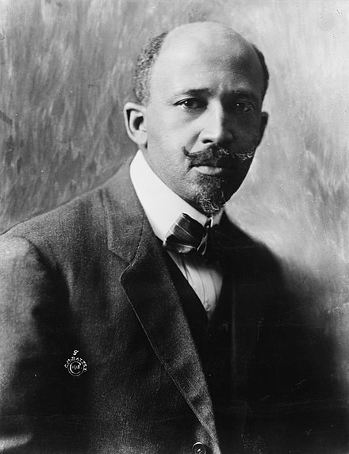

**The content of the following podcast, video, and images contains references to slavery, lynching, and the historical use of the word negro.**

- Scholar, historian, activist, and data scientist

  > "The Philadelphia Negro was the first scientific study of race in the world. [...] the first non-racist investigation of a non-white poulation in the world. [...] one of the first social scientific written in the U.S. using the advanced statistical methods of the time." - Dr. Tukufu Zuberi, Professor of Race Relations at the University of Pennsylvania (Source: [A Legacy of Courage: W.E.B. Du Bois and the Philadelphia Negro](https://youtu.be/PQX_0uyDgGw))
- First Black American to receive a PhD from Harvard
- NAACP founder
- Made a series of visualizations for the 1900 Paris Exposition
  - Goal: change the way people see Black Americans
  - Hundreds of photographs and patents
  - 60+ handmade graphs in 3 months

  > "All art is propaganda, and ever must be, despite the wailing of the purists. I stand in utter shamelessness and say that whatever art I have for writing has been used always for propaganda for gaining the right of black folk to love and enjoy. I do not care a damn for any art that is not used for propaganda." - W.E.B. Du Bois
- Typically compared with Booker T. Washington.

The following podcast provides an 11 minutes overview of these two leaders.

```python
# The content contains references to slavery, lynching, and the historical use of the word negro.
from IPython.display import IFrame
IFrame('https://open.spotify.com/embed/episode/6MdipyUuPK2bbXF0n2CYA1?utm_source=generator',
       width=500, height=350)
```

### Images from Paris Exposition

Image Sources:

- [Smithsonian Magazine - W.E.B. Du Bois’ Visionary Infographics Come Together for the First Time in Full Color](https://www.smithsonianmag.com/history/first-time-together-and-color-book-displays-web-du-bois-visionary-infographics-180970826/#)
- [WBUR - W.E.B. Du Bois Created These Infographics In 1900 To Humanize The African-American Experience](https://www.wbur.org/news/2019/02/21/web-du-bois-infographics-humanity-african-american)

[figure not shown]

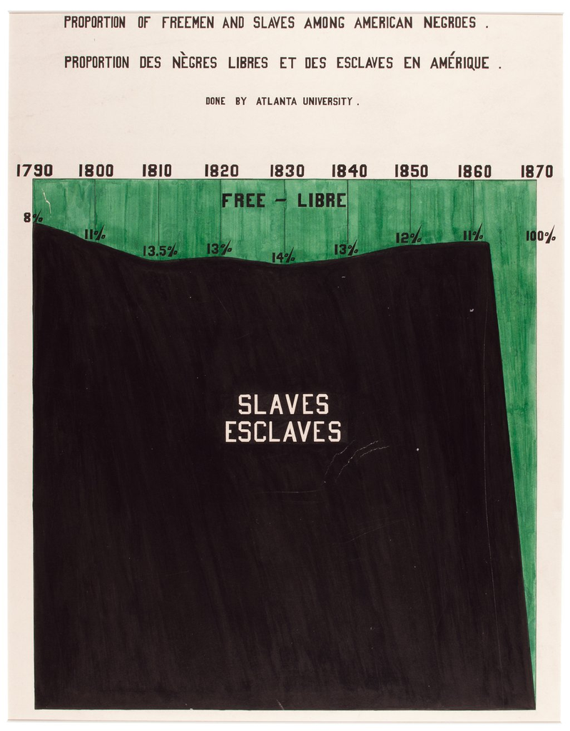

[figure not shown]

### Demo: Reading a Table from a File

Read the `du_bois.csv` data as a table.

```python
# this data set is from graphic just above
# CALSS is annual salary; rent, food, clothes, taxes, other are proportions
du_bois = Table.read_table('./data/du_bois.csv')
du_bois
```

| CLASS | ACTUAL AVERAGE | RENT | FOOD | CLOTHES | TAXES | OTHER | STATUS |
| --- | --- | --- | --- | --- | --- | --- | --- |
| 100-200 | 139.1 | 0.19 | 0.43 | 0.28 | 0.001 | 0.099 | POOR |
| 200-300 | 249.45 | 0.22 | 0.47 | 0.23 | 0.04 | 0.04 | POOR |
| 300-400 | 335.66 | 0.23 | 0.43 | 0.18 | 0.045 | 0.115 | FAIR |
| 400-500 | 433.82 | 0.18 | 0.37 | 0.15 | 0.055 | 0.245 | FAIR |
| 500-750 | 547 | 0.13 | 0.31 | 0.17 | 0.05 | 0.34 | COMFORTABLE |
| 750-1000 | 880 | 0 | 0.37 | 0.19 | 0.08 | 0.36 | COMFORTABLE |
| 1000 and over | 1125 | 0 | 0.29 | 0.16 | 0.045 | 0.505 | WELL-TO-DO |

Find the income bracket (`CLASS`) that spent the highest percentage of their income on rent.

```python
# first sort, then pluck out appropriate cell
du_bois.sort('RENT', descending=True)
du_bois.sort('RENT', descending=True).column('CLASS').item(0)
```

```
'300-400'
```

Explore the table using `select`, `column`

```python
# look at difference between select and column
du_bois.select('STATUS')
```

| STATUS |
| --- |
| POOR |
| POOR |
| FAIR |
| FAIR |
| COMFORTABLE |
| COMFORTABLE |
| WELL-TO-DO |

```python
du_bois.column('STATUS')
```

```
array(['POOR', 'POOR', 'FAIR', 'FAIR', 'COMFORTABLE', 'COMFORTABLE',
       'WELL-TO-DO'],
      dtype='<U11')
```

```python
# want to do arithmetic, so use array form
# look at how much each class paid for food on average (in $ amount)
du_bois.column('ACTUAL AVERAGE')
```

```
array([  139.1 ,   249.45,   335.66,   433.82,   547.  ,   880.  ,  1125.  ])
```

```python
du_bois.column('FOOD')
```

```
array([ 0.43,  0.47,  0.43,  0.37,  0.31,  0.37,  0.29])
```

```python
du_bois.column('ACTUAL AVERAGE') * du_bois.column('FOOD')
```

```
array([  59.813 ,  117.2415,  144.3338,  160.5134,  169.57  ,  325.6   ,
        326.25  ])
```

Add a column to the table showing the dollar amount for food based on the presented average.

```python
# name the new array
food_dollars = du_bois.column('ACTUAL AVERAGE') * du_bois.column('FOOD')
# attach to the table
du_bois = du_bois.with_column(
    '$ on Food', food_dollars
)
du_bois
```

| CLASS | ACTUAL AVERAGE | RENT | FOOD | CLOTHES | TAXES | OTHER | STATUS | $ on Food |
| --- | --- | --- | --- | --- | --- | --- | --- | --- |
| 100-200 | 139.1 | 0.19 | 0.43 | 0.28 | 0.001 | 0.099 | POOR | 59.813 |
| 200-300 | 249.45 | 0.22 | 0.47 | 0.23 | 0.04 | 0.04 | POOR | 117.241 |
| 300-400 | 335.66 | 0.23 | 0.43 | 0.18 | 0.045 | 0.115 | FAIR | 144.334 |
| 400-500 | 433.82 | 0.18 | 0.37 | 0.15 | 0.055 | 0.245 | FAIR | 160.513 |
| 500-750 | 547 | 0.13 | 0.31 | 0.17 | 0.05 | 0.34 | COMFORTABLE | 169.57 |
| 750-1000 | 880 | 0 | 0.37 | 0.19 | 0.08 | 0.36 | COMFORTABLE | 325.6 |
| 1000 and over | 1125 | 0 | 0.29 | 0.16 | 0.045 | 0.505 | WELL-TO-DO | 326.25 |

Format the `Food` column as a percent using the `set_format` method.

```python
# to format as a percent, use .set_format and PercentFormatter
du_bois.set_format('FOOD', PercentFormatter)
```

| CLASS | ACTUAL AVERAGE | RENT | FOOD | CLOTHES | TAXES | OTHER | STATUS | $ on Food |
| --- | --- | --- | --- | --- | --- | --- | --- | --- |
| 100-200 | 139.1 | 0.19 | 43.00% | 0.28 | 0.001 | 0.099 | POOR | 59.813 |
| 200-300 | 249.45 | 0.22 | 47.00% | 0.23 | 0.04 | 0.04 | POOR | 117.241 |
| 300-400 | 335.66 | 0.23 | 43.00% | 0.18 | 0.045 | 0.115 | FAIR | 144.334 |
| 400-500 | 433.82 | 0.18 | 37.00% | 0.15 | 0.055 | 0.245 | FAIR | 160.513 |
| 500-750 | 547 | 0.13 | 31.00% | 0.17 | 0.05 | 0.34 | COMFORTABLE | 169.57 |
| 750-1000 | 880 | 0 | 37.00% | 0.19 | 0.08 | 0.36 | COMFORTABLE | 325.6 |
| 1000 and over | 1125 | 0 | 29.00% | 0.16 | 0.045 | 0.505 | WELL-TO-DO | 326.25 |

```python
...
```

```python
...
```

## Table Methods and Attributes

- Creating and extending tables: `Table().with_column` and `Table.read_table`
- Finding the size: `num_rows` and `num_columns`
- Referring to columns: labels, relabeling, and indices
  - `labels` and `relabeled`; column indices start at 0
- Accessing data in a column: `column` takes a label or index and returns an array
- Using array methods to work with data in columns: `item`, `sum`, `min`, `max`, and so on
- Creating new tables containing some of the original columns: `select`, `drop`

### Demo: Selecting Data in a Column

Explore the `top_movies_1995_2022.csv` data set from [www.the-numbers.com/market](https://www.the-numbers.com/market/) trying to implement several of the methods used so far. Also, preview the `plot` method.

```python
# didn't get to in class
movies = Table.read_table('./data/top_movies_1995_2022.csv')
movies
```

| Year | Movie | MPAA Rating | Distributor | Total for Year ($) | Total in 2020 dollars | Tickets Sold |
| --- | --- | --- | --- | --- | --- | --- |
| 1995 | Batman Forever | PG-13 | Warner Bros. | 18403111200 | 38794603800 | 4230600200 |
| 1996 | Independence Day | PG-13 | 20th Century Fox | 30616925500 | 63519729900 | 6926906200 |
| 1997 | Men in Black | PG-13 | Sony Pictures | 25065005200 | 50075402100 | 5460785400 |
| 1998 | Titanic | PG-13 | Paramount Pictures | 44331908100 | 86678805100 | 9452432400 |
| 1999 | Star Wars Ep. I: The Phantom Menace | PG | 20th Century Fox | 43044335000 | 77700107800 | 8473294200 |
| 2000 | How the Grinch Stole Christmas | PG | Universal | 25336745500 | 43105371300 | 4700694800 |
| 2001 | Harry Potter and the Sorcerer’s Stone | PG | Warner Bros. | 30040443400 | 48669764000 | 5307498800 |
| 2002 | Spider-Man | PG-13 | Sony Pictures | 40370637500 | 63717512100 | 6948474600 |
| 2003 | Finding Nemo | G | Walt Disney | 33971436700 | 51661372000 | 5633737400 |
| 2004 | Shrek 2 | PG | Dreamworks SKG | 44122624700 | 65153698200 | 7105092500 |

... (18 rows omitted)

Calculate the average ticket price and add that information to the table.

```python
# create an array for first 2 then do array arithmetic to get third array
total_gross = movies.column('Total for Year ($)')
number_of_tickets_sold = movies.column('Tickets Sold')
ave_ticket_price = total_gross / number_of_tickets_sold
ave_ticket_price
```

```
array([ 4.35000008,  4.42000001,  4.59000004,  4.69000002,  5.08000005,
        5.39000011,  5.66000004,  5.81000001,  6.03000003,  6.21000004,
        6.41000011,  6.55000002,  6.88000003,  7.17999995,  7.5       ,
        7.89000002,  7.93      ,  7.96000002,  8.13000008,  8.17000009,
        8.43000003,  8.65      ,  8.97000009,  9.11000005,  9.15999998,
        9.17000018,  9.16999995,  9.17000006])
```

```python
# add the column produced above
movies = movies.with_column(
    'Average Ticket Price ($)', ave_ticket_price
)
movies
```

| Year | Movie | MPAA Rating | Distributor | Total for Year ($) | Total in 2020 dollars | Tickets Sold | Average Ticket Price ($) |
| --- | --- | --- | --- | --- | --- | --- | --- |
| 1995 | Batman Forever | PG-13 | Warner Bros. | 18403111200 | 38794603800 | 4230600200 | 4.35 |
| 1996 | Independence Day | PG-13 | 20th Century Fox | 30616925500 | 63519729900 | 6926906200 | 4.42 |
| 1997 | Men in Black | PG-13 | Sony Pictures | 25065005200 | 50075402100 | 5460785400 | 4.59 |
| 1998 | Titanic | PG-13 | Paramount Pictures | 44331908100 | 86678805100 | 9452432400 | 4.69 |
| 1999 | Star Wars Ep. I: The Phantom Menace | PG | 20th Century Fox | 43044335000 | 77700107800 | 8473294200 | 5.08 |
| 2000 | How the Grinch Stole Christmas | PG | Universal | 25336745500 | 43105371300 | 4700694800 | 5.39 |
| 2001 | Harry Potter and the Sorcerer’s Stone | PG | Warner Bros. | 30040443400 | 48669764000 | 5307498800 | 5.66 |
| 2002 | Spider-Man | PG-13 | Sony Pictures | 40370637500 | 63717512100 | 6948474600 | 5.81 |
| 2003 | Finding Nemo | G | Walt Disney | 33971436700 | 51661372000 | 5633737400 | 6.03 |
| 2004 | Shrek 2 | PG | Dreamworks SKG | 44122624700 | 65153698200 | 7105092500 | 6.21 |

... (18 rows omitted)

Format the numbers using the `set_format` table method.

```python
# We can make the numbers easier to look at
movies.set_format(['Total for Year ($)', 'Total in 2020 dollars', 'Tickets Sold'], NumberFormatter)
```

| Year | Movie | MPAA Rating | Distributor | Total for Year ($) | Total in 2020 dollars | Tickets Sold | Average Ticket Price ($) |
| --- | --- | --- | --- | --- | --- | --- | --- |
| 1995 | Batman Forever | PG-13 | Warner Bros. | 18,403,111,200 | 38,794,603,800 | 4,230,600,200 | 4.35 |
| 1996 | Independence Day | PG-13 | 20th Century Fox | 30,616,925,500 | 63,519,729,900 | 6,926,906,200 | 4.42 |
| 1997 | Men in Black | PG-13 | Sony Pictures | 25,065,005,200 | 50,075,402,100 | 5,460,785,400 | 4.59 |
| 1998 | Titanic | PG-13 | Paramount Pictures | 44,331,908,100 | 86,678,805,100 | 9,452,432,400 | 4.69 |
| 1999 | Star Wars Ep. I: The Phantom Menace | PG | 20th Century Fox | 43,044,335,000 | 77,700,107,800 | 8,473,294,200 | 5.08 |
| 2000 | How the Grinch Stole Christmas | PG | Universal | 25,336,745,500 | 43,105,371,300 | 4,700,694,800 | 5.39 |
| 2001 | Harry Potter and the Sorcerer’s Stone | PG | Warner Bros. | 30,040,443,400 | 48,669,764,000 | 5,307,498,800 | 5.66 |
| 2002 | Spider-Man | PG-13 | Sony Pictures | 40,370,637,500 | 63,717,512,100 | 6,948,474,600 | 5.81 |
| 2003 | Finding Nemo | G | Walt Disney | 33,971,436,700 | 51,661,372,000 | 5,633,737,400 | 6.03 |
| 2004 | Shrek 2 | PG | Dreamworks SKG | 44,122,624,700 | 65,153,698,200 | 7,105,092,500 | 6.21 |

... (18 rows omitted)

Show the trend of average ticket prices over time.

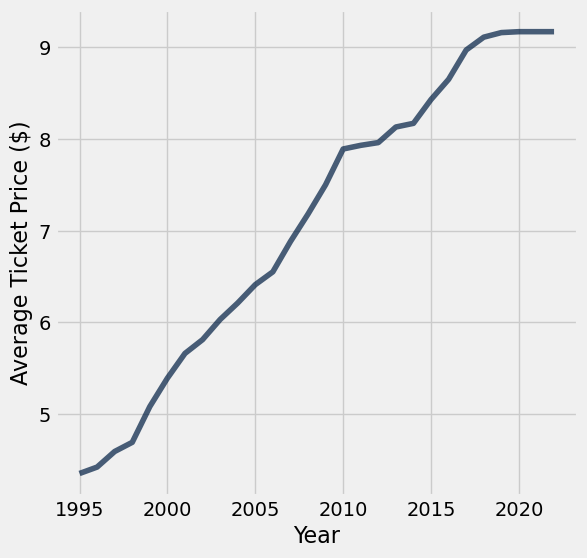

```python
# A Line Plot
movies.plot('Year', 'Average Ticket Price ($)')
```

Be careful of interpreting this! Using the actual gross totals for each each doesn't consider inflation.

Practice filtering the data using the `where` and `take` table methods.

```python
# filtering years 2000 to 2004
movies.where('Year', are.between(2000, 2005))
```

| Year | Movie | MPAA Rating | Distributor | Total for Year ($) | Total in 2020 dollars | Tickets Sold | Average Ticket Price ($) |
| --- | --- | --- | --- | --- | --- | --- | --- |
| 2000 | How the Grinch Stole Christmas | PG | Universal | 25,336,745,500 | 43,105,371,300 | 4,700,694,800 | 5.39 |
| 2001 | Harry Potter and the Sorcerer’s Stone | PG | Warner Bros. | 30,040,443,400 | 48,669,764,000 | 5,307,498,800 | 5.66 |
| 2002 | Spider-Man | PG-13 | Sony Pictures | 40,370,637,500 | 63,717,512,100 | 6,948,474,600 | 5.81 |
| 2003 | Finding Nemo | G | Walt Disney | 33,971,436,700 | 51,661,372,000 | 5,633,737,400 | 6.03 |
| 2004 | Shrek 2 | PG | Dreamworks SKG | 44,122,624,700 | 65,153,698,200 | 7,105,092,500 | 6.21 |

```python
# just the 2022 line
movies.where('Year', 2022)
```

| Year | Movie | MPAA Rating | Distributor | Total for Year ($) | Total in 2020 dollars | Tickets Sold | Average Ticket Price ($) |
| --- | --- | --- | --- | --- | --- | --- | --- |
| 2022 | Top Gun: Maverick | PG-13 | Paramount Pictures | 71,873,282,100 | 71,873,281,700 | 7,837,871,500 | 9.17 |

```python
# same as above
movies.where('Year', are.equal_to(2022))
```

| Year | Movie | MPAA Rating | Distributor | Total for Year ($) | Total in 2020 dollars | Tickets Sold | Average Ticket Price ($) |
| --- | --- | --- | --- | --- | --- | --- | --- |
| 2022 | Top Gun: Maverick | PG-13 | Paramount Pictures | 71,873,282,100 | 71,873,281,700 | 7,837,871,500 | 9.17 |

```python
# looking for Harry Potter
movies.where('Movie', are.containing('Harry Potter'))
```

| Year | Movie | MPAA Rating | Distributor | Total for Year ($) | Total in 2020 dollars | Tickets Sold | Average Ticket Price ($) |
| --- | --- | --- | --- | --- | --- | --- | --- |
| 2001 | Harry Potter and the Sorcerer’s Stone | PG | Warner Bros. | 30,040,443,400 | 48,669,764,000 | 5,307,498,800 | 5.66 |
| 2011 | Harry Potter and the Deathly Hallows: Part II | PG-13 | Warner Bros. | 38,101,121,900 | 44,058,926,600 | 4,804,681,200 | 7.93 |

```python
# takes rows 3, 4 and 5
movies.take(np.arange(2, 5))
```

| Year | Movie | MPAA Rating | Distributor | Total for Year ($) | Total in 2020 dollars | Tickets Sold | Average Ticket Price ($) |
| --- | --- | --- | --- | --- | --- | --- | --- |
| 1997 | Men in Black | PG-13 | Sony Pictures | 25,065,005,200 | 50,075,402,100 | 5,460,785,400 | 4.59 |
| 1998 | Titanic | PG-13 | Paramount Pictures | 44,331,908,100 | 86,678,805,100 | 9,452,432,400 | 4.69 |
| 1999 | Star Wars Ep. I: The Phantom Menace | PG | 20th Century Fox | 43,044,335,000 | 77,700,107,800 | 8,473,294,200 | 5.08 |